# Semana 03- code sessions

## Analisis del experimento

### Veamos diferencias en aprendizaje por tamano de la clase

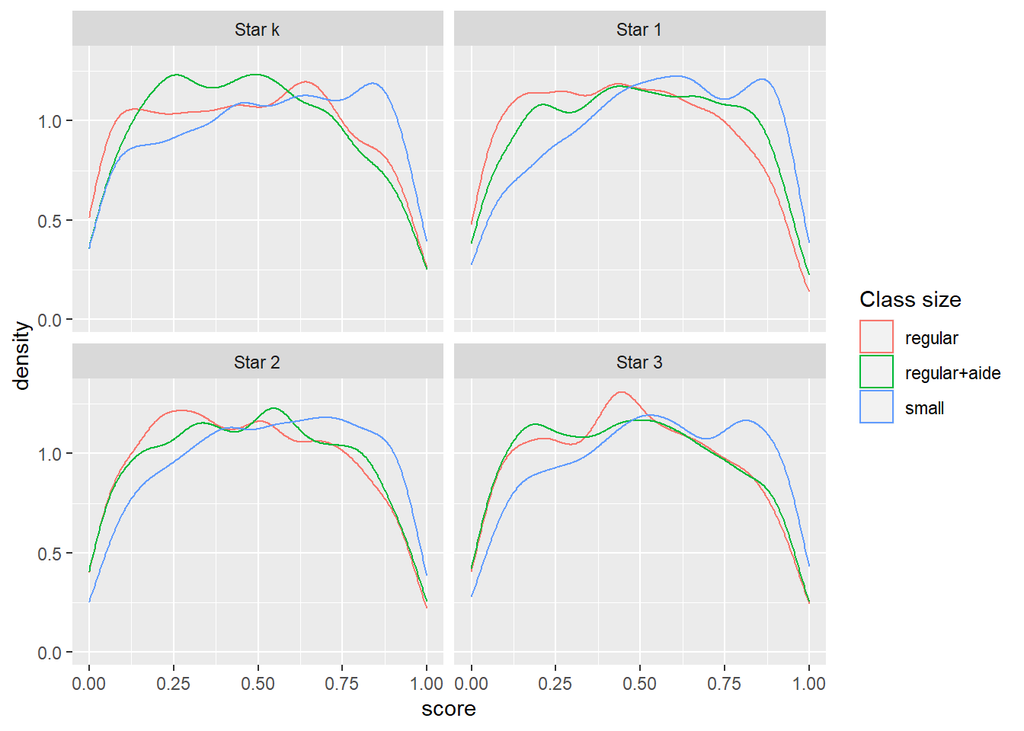

```r
# make a density plot
ggplot(data = STAR_long,
       mapping = aes(x = score,
                     color=factor(star,
                                  levels = c("regular",
                                             "regular+aide",
                                             "small")))) +
  geom_density() +
  # Este comando te permite segmentar un grafico de ggplot sobre segmentos de la data
  # creando un panel de graficos para cada uno de estos
  facet_wrap(~ factor(paste0("Star ",grade),
                      levels = c("Star k","Star 1",
                                 "Star 2","Star 3"))) +
  labs(color="Class size")
```

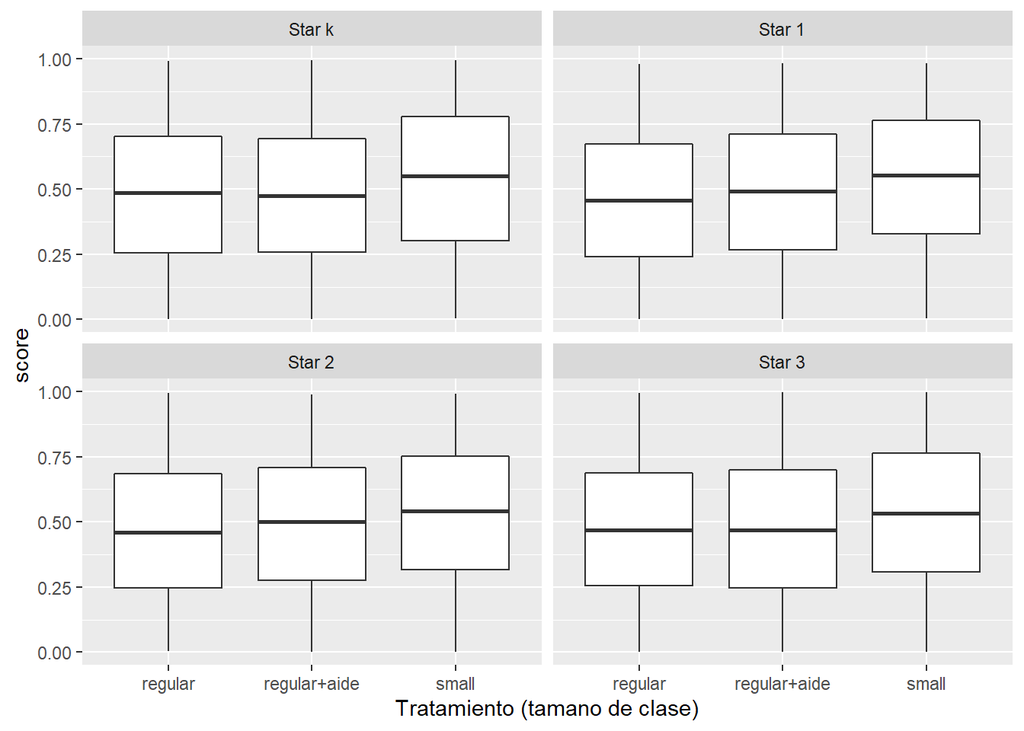

```r
# make a boxplot
ggplot(data = drop_na(STAR_long),
       mapping = aes(x = factor(star,
                                  levels = c("regular",
                                             "regular+aide",
                                             "small")),
                     y=score)) +
  geom_boxplot() +
  facet_wrap(~ factor(paste0("Star ",grade),
                      levels = c("Star k","Star 1",
                                 "Star 2","Star 3"))) +
  labs(color="Class size",
       x="Tratamiento (tamano de clase)")
```

### Como saber si estan bien randomizados?

Para saber que tal funcionó la randomización debemos fijarnos en que tan balanceadas están las composiciones de las muestras en distintos atributos demográficos, cómo etnografia, genero, e incluso attrition (porcentaje que se salio de la muestra inicial).

Tabla 2.2.1, MHE

Valores directamente extraidos de la fuente

| Variable | Small | Regular | Regular + Aide | P-value |
| --- | --- | --- | --- | --- |
| Free lunch | 0.47 | 0.48 | 0.50 | 0.09 |
| White/Asian | 0.68 | 0.67 | 0.66 | 0.26 |
| Age in 1985 | 5.44 | 5.43 | 5.42 | 0.32 |
| Attrition rate | 0.49 | 0.52 | 0.53 | 0.02 |
| K. class size | 15.10 | 22.40 | 22.80 | 0.00 |
| K. test percentile | 54.70 | 48.90 | 50.00 | 0.00 |

### Repasemos como hacer esta tabla

```r
# Intento de replicar la tabla 2.2.1 de MHE
# All variables are for the first year a student is observed
# Here we filter the table to fulfill that
tabla_stats<-STAR_long %>%
  group_by(id) %>%
  mutate(grade_num=as.numeric(ifelse(grade=="k","0",grade))) %>%
  filter(grade_num==min(grade_num)) %>%
  # recuerda aplicar ungroup despues de usar group_by: mejora velocidad y previene errores
  ungroup() %>%
  # one of the rows reffers to white/assian, so we create a variable that blends these groups
  # carefull about the factor vs character format, it can cause errors
  mutate(ethnicity=as.character(ethnicity),
         table_etnicity=ifelse(ethnicity %in% c("cauc","asian"),
                               "white/asian",ethnicity)) %>%
  # Another variable we need to create is age in 1985
  mutate(age=1985-birth)

#  The P-value in the last column is for the F-test of equality of variable means across all three groups.
# This functions pulls the joint p value from a regression object
lmp <- function (modelobject) {
  # le anades un modelo lm. Ej: lm(precio~cantidad, data=mercado)
  # si no es un objeto lm, te arrojara un mensaje de error
    if (class(modelobject) != "lm") stop("Not an object of class 'lm' ")
    # extraemos el elemento fstatistic de esos resultados
    f <- summary(modelobject)$fstatistic
    # con el f, y los grados de libertad, extraemos el joint p-value
    p <- pf(f[1],f[2],f[3],lower.tail=F)
    # limpiamos el joint p-value para que sea un numero "plano": sin atributos
    attributes(p) <- NULL
    return(p)
}

## En clase lo haremos para algunas variables:
# free_lunch (clase)
# white/asian (clase)
# age in 1985 (clase)
# Attrition rate (no lo haremos, pero revisen en MHE que se trata y repasen implicaciones)
# k. class size (no lo haremos, pero revisen en MHE que se trata y repasen implicaciones)
# k. test percentile (clase)
```

```r
kinder_table<-tabla_stats %>%
  filter(grade=="k")

score_data<-kinder_table%>%
  group_by(star) %>%
  summarise(score=mean(score, na.rm = T)) %>%
  tidyr::pivot_wider(names_from = star, values_from=score) %>%
  mutate(p_value=lmp(lm(score~star,data=tabla_stats )))%>%
  mutate(variable="Score promedio en Kinder")

dplyr::bind_rows(free_data,
                 white_asian_data,
                 age_data,
                 tab221_data %>%
                  filter(v1=="Attrition rate"|v1=="K. class size") %>%
                   rename(variable=v1, small=v2,regular=v3,`regular+aide`=v4,p_value=v5),
                 score_data) %>%
  select(variable, small,regular,`regular+aide`,p_value) %>%
  # Usamos el paquete gt:: para imprimir tablas en formato de publicacion
  # Revisenlo, es muy flexible para presentar resumenes de datos.
  # No es tan bueno para imprimir resultados de regresiones, para eso les recomiendo huxtable::
  gt() %>%
  gt::tab_header("Tabla 2.2.1, MHE ",
                 subtitle = "Adaptada usando datos de libreria AER::STARS") %>%
  gt::fmt_number(columns = 2:5)
```

Tabla 2.2.1, MHE

Adaptada usando datos de libreria AER::STARS

| variable | small | regular | regular+aide | p_value |
| --- | --- | --- | --- | --- |
| free lunch | 0.47 | 0.48 | 0.50 | 0.09 |
| white/asian | 0.68 | 0.67 | 0.66 | 0.25 |
| Edad | 4.89 | 4.88 | 4.89 | 0.62 |
| Attrition rate | 0.49 | 0.52 | 0.53 | 0.02 |
| K. class size | 15.10 | 22.40 | 22.80 | 0.00 |
| Score promedio en Kinder | 0.52 | 0.47 | 0.47 | 0.00 |

### Analisis de regresion

Fijense en las similitudes entre la tabla anterior y primera columna. ¿Cuales son y por que se dan?

```r
# Creemos las variables dummys de forma practica
kinder_table =  as_tibble(kinder_table) %>%
    mutate(girl  = gender == "female",
           freelunch = lunch == "free")

library(huxtable)
lm1<-lm(score ~ star , data=kinder_table )
lm2<-lm(score ~ star + schoolid, data = kinder_table)
lm3<-lm(score ~ star + schoolid + girl + lunch, data = kinder_table)

# la variable schoolid toma decenas de valores, tenemos que remover esos coeficientes de nuestra tabla. Usaremos el siguiente codigo.

# Extraemos el nombre de todos los coeficientes y extraemos los que empiezan con "schoolid"
school_co = grep(names(coef(lm2)),pattern = "schoolid*",value=T)
# nos aseguremos de incluir todos los schoolids en las regresiones
school_co = c(unique(school_co,grep(names(coef(lm2)),pattern = "schoolid*",value=T)),"schoolid77")

huxreg(lm1, lm2, lm3,
       omit_coefs = school_co,
       statistics = c("N. obs." = "nobs",
      "R squared" = "r.squared", "F statistic" = "statistic",
      "P value" = "p.value")) %>%
    huxtable::insert_row(c("School control (FE)","No","Yes","Yes"),after = 11)
```

|  | (1) | (2) | (3) |
| --- | --- | --- | --- |
| (Intercept) | 0.473 *** | 0.542 *** | 0.559 *** |
|  | (0.006) | (0.029) | (0.028) |
| starsmall | 0.049 *** | 0.057 *** | 0.057 *** |
|  | (0.009) | (0.008) | (0.008) |
| starregular+aide | -0.002 | 0.002 | 0.003 |
|  | (0.008) | (0.008) | (0.007) |
| girlTRUE |  |  | 0.047 *** |
|  |  |  | (0.006) |
| lunchfree |  |  | -0.142 *** |
|  |  |  | (0.007) |
| School control (FE) | No | Yes | Yes |
| N. obs. | 5786 | 5786 | 5769 |
| R squared | 0.007 | 0.251 | 0.307 |
| F statistic | 21.365 | 23.916 | 30.737 |
| P value | 0.000 | 0.000 | 0.000 |
| *** p < 0.001; ** p < 0.01; * p < 0.05. |  |  |  |

```r
## Para tarea, replicar tabla de regresion e interpretar resultados.
```

# Referencias:

- [Introduction to econometrics with R, by Oswald & Viers et al. 2020, SciencePo, Department of economics](https://scpoecon.github.io/ScPoEconometrics/STAR.html#implementing-star)
- [Ed Rubing Econometrics III lectures, The experimental ideal](https://github.com/edrubin/EC525S19)
- Mostly Harmless Econometrics, Angrist & Pischke 2008, Capitulo 2.

# Fuentes de consulta recomendadas para programacion en R:

- [Rstudio education](https://education.rstudio.com/learn/): Ofrecen las mejores guias para aprender R a cualquier nivel.
- [Rstudio tutorials](https://rstudio.cloud/learn/primers): Tutoriales interactivos gratuitos.
- [Rstudio cheatsheets](https://www.rstudio.com/resources/cheatsheets/): Necesitas despejar algunas dudas rápido? Revisa estas chuletas, son lo mejor.
- Limpieza y transformación de datos [(**dplry**, **tidyr**, **janitor**, **stringr**,**readr**)](https://www.rstudio.com/resources/cheatsheets/).
- Visualización de datos [(**ggplot2**)](https://rstudio.cloud/learn/primers/3).
- Tipos de objetos en R [(vectores, matrices, data.frames, tiblles, lists)](https://rstudio.cloud/learn/primers/2).
- Iteraciones [(for loops, lapply functions, the purr package)](https://rstudio.cloud/learn/primers/5).